# Business Problem

#### Lucky wants to buy a laptop in budget.

The online laptop market is highly competitive, with hundreds of models available across different brands, price ranges, and configurations. Customers make purchase decisions based on factors such as price, brand reputation, specifications (RAM, storage, processor), ratings, and reviews.

##### Lucky starts asking questions:

- How do specifications (RAM, SSD, processor) impact laptop pricing?
- Is there a relationship between price and customer ratings/reviews?
- Is there a relationship between price and customer ratings/reviews?
- What brand has high rating ?
- Which laptop brands are available the most?
- Do laptops with more RAM usually cost more?

### Business Problem Statement

To analyze the laptop market by web scraping e-commerce data in order to identify pricing trends, brand performance, and key factors influencing customer purchase decisions.

So, we will use Exploratory Data Analysis (EDA) to:

Compare prices across different brands

Analyze the relationship between ratings and price

Identify features that increase laptops prices

### EDA Goals

- Analyze the distribution of laptop prices in the online market
- Compare laptop prices across different brands
- Identify brands with the highest number of laptop listings
- Study how customer ratings vary across brands
- Analyze the relationship between laptop price and customer ratings

```python
import pandas as pd
import numpy as np
from selenium import webdriver
from selenium.webdriver.common.by import By
from selenium.webdriver.common.keys import Keys
from selenium.webdriver.chrome.service import Service
from selenium.webdriver.chrome.options import Options
from webdriver_manager.chrome import ChromeDriverManager
import matplotlib.pyplot as plt
import seaborn as sns
import re
import time
import warnings
warnings.filterwarnings("ignore")
```

```python
options=Options()
options.add_argument('--start-maximized')

service=Service(ChromeDriverManager().install())

driver=webdriver.Chrome(service=service,options=options)
```

```python
url = 'https://www.amazon.in/s?k=laptops&crid=C5XB8DR2QIHA&qid=1768815530&sprefix=laptops%2Caps%2C469&xpid=D4Mi51r1-oxLe&ref=sr_pg_1'
url
```

```
'https://www.amazon.in/s?k=laptops&crid=C5XB8DR2QIHA&qid=1768815530&sprefix=laptops%2Caps%2C469&xpid=D4Mi51r1-oxLe&ref=sr_pg_1'
```

```python
driver.get(url)
```

```python
a=driver.find_elements(By.CSS_SELECTOR,".a-size-small.a-color-base")[0].text
a
```

```
'3.9'
```

```python
a=driver.find_elements(By.CSS_SELECTOR,".a-size-small.a-color-base")
for i in a:
    print(i.text)
```

```
3.9
4.1
4.1
4.1
4.2
4.4
5.0
4.7
4.7
4.1
5
4.1
4.1
3.0
4.0
4.2
3.9
4.2
4.0
4.0
4.0
4.0
4.2
4.1
4.0
4.1
& Up
```

```python
RATING = []

for i in range(1, 21):
    print(f"Scraping Page {i}")

    url = f"https://www.amazon.in/s?k=laptops&page={i}"
    driver.get(url)
    time.sleep(3)

    elements = driver.find_elements(
        By.CSS_SELECTOR,
        ".a-size-small.a-color-base"
    )

    for el in elements:
        text = el.text.strip()

        if text:
            RATING.append(text)
        else:
            RATING.append(None)

RATING
```

```
Scraping Page 1
Scraping Page 2
Scraping Page 3
Scraping Page 4
Scraping Page 5
Scraping Page 6
Scraping Page 7
Scraping Page 8
Scraping Page 9
Scraping Page 10
Scraping Page 11
Scraping Page 12
Scraping Page 13
Scraping Page 14
Scraping Page 15
Scraping Page 16
Scraping Page 17
Scraping Page 18
Scraping Page 19
Scraping Page 20
```

```
['4.1',
 '4.4',
 '3.9',
 '4.1',
 '4.1',
 '4.1',
 '4.2',
 '4.4',
 '5.0',
 '4.7',
 '4.7',
 '4.1',
 '5',
 '4.1',
 '4.1',
 '3.0',
 '4.0',
 '4.2',
 '3.9',
 '4.1',
 '4.0',
 '4.2',
 '4.0',
 '4.0',
 '4.0',
 '4.0',
 '4.2',
 '4.1',
 '4.0',
 '5.0',
 '4.2',
 '4.1',
 '& Up',
 '4.4',
 '3.3',
 '4.0',
 '4.1',
 '3.8',
 '4.1',
 '4.0',
```

[output cut: 605 more lines]

```
 '5.0',
 '4.7',
 '4.1',
 '5',
 '4.0',
 '4.0',
 '4.1',
 '4.1',
 '4.2',
 '4.7',
 None,
 '3.7',
 '3.9',
 '4.0',
 '& Up']
```

```python
len(RATING)
```

```
660
```

```python
df = pd.DataFrame({
    'Rating': RATING
})
```

```python
df
```

|  | Rating |
| --- | --- |
| 0 | 4.1 |
| 1 | 4.4 |
| 2 | 3.9 |
| 3 | 4.1 |
| 4 | 4.1 |
| ... | ... |
| 655 | None |
| 656 | 3.7 |
| 657 | 3.9 |
| 658 | 4.0 |
| 659 | & Up |

660 rows × 1 columns

```python
Screen_Size = []

for i in range(1, 21):
    print(f"Scraping Page {i}")

    url = f"https://www.amazon.in/s?k=laptops&page={i}"
    driver.get(url)
    time.sleep(3)

    elements = driver.find_elements(
        By.CSS_SELECTOR,
        ".a-size-medium.a-color-base.a-text-normal"
    )

    for el in elements:
        text = el.text.strip()

        match = re.search(r'(\d{2}\.?\d?)\s*(?:\"|INCH)', text.upper())

        if match:
            Screen_Size.append(float(match.group(1)))
        else:
            Screen_Size.append(None)

Screen_Size
```

```
Scraping Page 1
Scraping Page 2
Scraping Page 3
Scraping Page 4
Scraping Page 5
Scraping Page 6
Scraping Page 7
Scraping Page 8
Scraping Page 9
Scraping Page 10
Scraping Page 11
Scraping Page 12
Scraping Page 13
Scraping Page 14
Scraping Page 15
Scraping Page 16
Scraping Page 17
Scraping Page 18
Scraping Page 19
Scraping Page 20
```

```
[None,
 15.3,
 14.0,
 15.6,
 14.0,
 None,
 None,
 14.1,
 None,
 15.6,
 None,
 14.0,
 None,
 None,
 15.6,
 None,
 None,
 15.6,
 15.6,
 15.6,
 16.0,
 None,
 15.6,
 None,
 None,
 14.0,
 None,
 11.6,
 None,
 None,
 14.0,
 None,
 15.6,
 14.0,
 15.6,
 None,
 14.0,
 None,
 15.6,
 None,
```

[output cut: 392 more lines]

```
 14.0,
 None,
 None,
 15.6,
 None,
 None,
 None,
 15.6,
 None,
 None,
 14.0,
 None,
 15.6,
 None,
 None]
```

```python
len(Screen_Size)
```

```
447
```

```python
import re
import time
from selenium.webdriver.common.by import By

Color = []

for i in range(1, 21):
    print(f"Scraping Page {i}")

    url = f"https://www.amazon.in/s?k=laptops&page={i}"
    driver.get(url)
    time.sleep(3)

    elements = driver.find_elements(
        By.CSS_SELECTOR,
        ".a-size-medium.a-color-base.a-text-normal"
    )

    for el in elements:
        text = el.text.strip()


        match = re.search(
            r'\b(BLACK|SILVER|GREY|GRAY|BLUE|WHITE|RED|GOLD|GREEN|PINK)\b',
            text.upper()
        )

        if match:
            Color.append(match.group(1).title())
        else:
            Color.append(None)

Color
```

```
Scraping Page 1
Scraping Page 2
Scraping Page 3
Scraping Page 4
Scraping Page 5
Scraping Page 6
Scraping Page 7
Scraping Page 8
Scraping Page 9
Scraping Page 10
Scraping Page 11
Scraping Page 12
Scraping Page 13
Scraping Page 14
Scraping Page 15
Scraping Page 16
Scraping Page 17
Scraping Page 18
Scraping Page 19
Scraping Page 20
```

```
['Silver',
 'Grey',
 'Silver',
 'Blue',
 'Black',
 'Silver',
 'Silver',
 'Silver',
 'Grey',
 'Silver',
 'Blue',
 'Silver',
 'Silver',
 'Silver',
 'Silver',
 'Silver',
 'Silver',
 'Grey',
 'Grey',
 'Black',
 'Gray',
 'Grey',
 'Black',
 None,
 'Silver',
 'Grey',
 'Silver',
 'Blue',
 'Black',
 'Silver',
 'Gray',
 None,
 'Blue',
 'Black',
 'Grey',
 'Silver',
 'Grey',
 'Silver',
 'Blue',
 'Silver',
```

[output cut: 392 more lines]

```
 None,
 None,
 'Grey',
 'Silver',
 'Silver',
 'Silver',
 'Silver',
 'Grey',
 'White',
 'Black',
 'Silver',
 'Grey',
 'Silver',
 'Silver',
 'Black']
```

```python
len(
Color)
```

```
447
```

```python
import re
import time
from selenium.webdriver.common.by import By

Weight_kg = []

for i in range(1, 21):
    print(f"Scraping Page {i}")

    url = f"https://www.amazon.in/s?k=laptops&page={i}"
    driver.get(url)
    time.sleep(3)

    elements = driver.find_elements(
        By.CSS_SELECTOR,
        ".a-size-medium.a-color-base.a-text-normal"
    )

    for el in elements:
        text = el.text.strip()


        match = re.search(
            r'(\d+(?:\.\d+)?)\s*KG',
            text.upper()
        )

        if match:
            Weight_kg.append(float(match.group(1)))
        else:
            Weight_kg.append(None)

Weight_kg
```

```
Scraping Page 1
Scraping Page 2
Scraping Page 3
Scraping Page 4
Scraping Page 5
Scraping Page 6
Scraping Page 7
Scraping Page 8
Scraping Page 9
Scraping Page 10
Scraping Page 11
Scraping Page 12
Scraping Page 13
Scraping Page 14
Scraping Page 15
Scraping Page 16
Scraping Page 17
Scraping Page 18
Scraping Page 19
Scraping Page 20
```

```
[1.35,
 1.6,
 1.51,
 1.7,
 1.38,
 1.35,
 1.59,
 1.3,
 1.59,
 1.59,
 1.7,
 1.4,
 1.41,
 1.59,
 1.7,
 1.65,
 2.29,
 1.6,
 None,
 2.3,
 2.2,
 1.7,
 None,
 None,
 1.35,
 1.6,
 1.59,
 1.21,
 1.95,
 1.59,
 1.5,
 None,
 1.7,
 1.46,
 1.41,
 1.4,
 1.43,
 1.7,
 None,
 1.59,
```

[output cut: 392 more lines]

```
 None,
 None,
 None,
 1.38,
 1.36,
 None,
 1.35,
 1.7,
 5.0,
 None,
 1.6,
 1.36,
 1.6,
 1.38,
 1.35]
```

```python
import pandas as pd

df = pd.DataFrame({
    'Screen_Size_Inch': Screen_Size,
    'Color': Color,
    'Weight_kg': Weight_kg
})

df
```

|  | Screen_Size_Inch | Color | Weight_kg |
| --- | --- | --- | --- |
| 0 | NaN | Silver | 1.35 |
| 1 | 15.3 | Grey | 1.60 |
| 2 | 14.0 | Silver | 1.51 |
| 3 | 15.6 | Blue | 1.70 |
| 4 | 14.0 | Black | 1.38 |
| ... | ... | ... | ... |
| 442 | 14.0 | Silver | 1.60 |
| 443 | NaN | Grey | 1.36 |
| 444 | 15.6 | Silver | 1.60 |
| 445 | NaN | Silver | 1.38 |
| 446 | NaN | Black | 1.35 |

447 rows × 3 columns

```python
df.to_csv("EDA3.csv", index=False)
df.to_excel("EDA3.xlsx", index=False)
```

```python
import pandas as pd
import numpy as np
import matplotlib.pyplot as mlt
import seaborn as sns
```

### Data Importing

```python
df1 = pd.read_excel(r"C:\Users\thiru\Laptop_Data.xlsx")
df1
```

|  | Brand | CPU | RAM | PRICE |
| --- | --- | --- | --- | --- |
| 0 | HP | NaN | 16GB | NaN |
| 1 | HP | NaN | 16GB | 2025.0 |
| 2 | Ienovo | NaN | 8GB | 116990.0 |
| 3 | Neopticon | NaN | 4GB | 2025.0 |
| 4 | ASUS | AMD Ryzen 3 7320U | 8GB | 164490.0 |
| ... | ... | ... | ... | ... |
| 442 | HP | Intel Core i5-1334U | 16GB | 164490.0 |
| 443 | HP | Intel Core i5-13420H | 4GB | 2024.0 |
| 444 | Lenovo | NaN | 16GB | 195990.0 |
| 445 | ASUS | NaN | 16GB | 70999.0 |
| 446 | MENHOOD | NaN | NaN | 85965.0 |

447 rows × 4 columns

```python
df2 = pd.read_excel(r"C:\Users\thiru\Rating_Data.xlsx")
df2
```

|  | Rating |
| --- | --- |
| 0 | 4.1 |
| 1 | 4.1 |
| 2 | 4.1 |
| 3 | 3.0 |
| 4 | 4.1 |
| ... | ... |
| 639 | NaN |
| 640 | 3.9 |
| 641 | 3.8 |
| 642 | 4.0 |
| 643 | & Up |

644 rows × 1 columns

### Data Concatenating

```python
df_large = df1.reset_index(drop=True)
df_small = df2.reset_index(drop=True)
df = pd.concat([df_small.iloc[:447], df_large], axis=1)
```

```python
df
```

|  | Rating | Brand | CPU | RAM | PRICE |
| --- | --- | --- | --- | --- | --- |
| 0 | 4.1 | HP | NaN | 16GB | NaN |
| 1 | 4.1 | HP | NaN | 16GB | 2025.0 |
| 2 | 4.1 | Ienovo | NaN | 8GB | 116990.0 |
| 3 | 3.0 | Neopticon | NaN | 4GB | 2025.0 |
| 4 | 4.1 | ASUS | AMD Ryzen 3 7320U | 8GB | 164490.0 |
| ... | ... | ... | ... | ... | ... |
| 442 | 3.9 | HP | Intel Core i5-1334U | 16GB | 164490.0 |
| 443 | 3.3 | HP | Intel Core i5-13420H | 4GB | 2024.0 |
| 444 | 4.3 | Lenovo | NaN | 16GB | 195990.0 |
| 445 | 4.1 | ASUS | NaN | 16GB | 70999.0 |
| 446 | 4.1 | MENHOOD | NaN | NaN | 85965.0 |

447 rows × 5 columns

```python
df.info()
```

```
<class 'pandas.core.frame.DataFrame'>
RangeIndex: 447 entries, 0 to 446
Data columns (total 5 columns):
 #   Column  Non-Null Count  Dtype
---  ------  --------------  -----
 0   Rating  435 non-null    object
 1   Brand   439 non-null    object
 2   CPU     75 non-null     object
 3   RAM     210 non-null    object
 4   PRICE   425 non-null    float64
dtypes: float64(1), object(4)
memory usage: 17.6+ KB
```

```python
df.isna().sum()
```

```
Rating     12
Brand       8
CPU       372
RAM       237
PRICE      22
dtype: int64
```

```python
df.isna().value_counts()
```

```
Rating  Brand  CPU    RAM    PRICE
False   False  True   True   False    216
                      False  False    119
               False  False  False     71
               True   False  True      11
                      True   True       7
True    False  True   True   False      7
False   True   True   True   False      6
        False  False  False  True       4
True    False  True   False  False      4
False   True   True   False  False      1
True    True   True   True   False      1
Name: count, dtype: int64
```

### Filling Missing Values

```python
df['PRICE'].mean()
```

```
np.float64(47922.717647058824)
```

```python
df['PRICE'].fillna(df['PRICE'].mean(),inplace = True)
df
```

|  | Rating | Brand | CPU | RAM | PRICE |
| --- | --- | --- | --- | --- | --- |
| 0 | 4.1 | HP | NaN | 16GB | 47922.717647 |
| 1 | 4.1 | HP | NaN | 16GB | 2025.000000 |
| 2 | 4.1 | Ienovo | NaN | 8GB | 116990.000000 |
| 3 | 3.0 | Neopticon | NaN | 4GB | 2025.000000 |
| 4 | 4.1 | ASUS | AMD Ryzen 3 7320U | 8GB | 164490.000000 |
| ... | ... | ... | ... | ... | ... |
| 442 | 3.9 | HP | Intel Core i5-1334U | 16GB | 164490.000000 |
| 443 | 3.3 | HP | Intel Core i5-13420H | 4GB | 2024.000000 |
| 444 | 4.3 | Lenovo | NaN | 16GB | 195990.000000 |
| 445 | 4.1 | ASUS | NaN | 16GB | 70999.000000 |
| 446 | 4.1 | MENHOOD | NaN | NaN | 85965.000000 |

447 rows × 5 columns

```python
df['PRICE'] = df['PRICE'].astype(int)
df
```

|  | Rating | Brand | CPU | RAM | PRICE |
| --- | --- | --- | --- | --- | --- |
| 0 | 4.1 | HP | NaN | 16GB | 47922 |
| 1 | 4.1 | HP | NaN | 16GB | 2025 |
| 2 | 4.1 | Ienovo | NaN | 8GB | 116990 |
| 3 | 3.0 | Neopticon | NaN | 4GB | 2025 |
| 4 | 4.1 | ASUS | AMD Ryzen 3 7320U | 8GB | 164490 |
| ... | ... | ... | ... | ... | ... |
| 442 | 3.9 | HP | Intel Core i5-1334U | 16GB | 164490 |
| 443 | 3.3 | HP | Intel Core i5-13420H | 4GB | 2024 |
| 444 | 4.3 | Lenovo | NaN | 16GB | 195990 |
| 445 | 4.1 | ASUS | NaN | 16GB | 70999 |
| 446 | 4.1 | MENHOOD | NaN | NaN | 85965 |

447 rows × 5 columns

```python
df['Rating'].mode()
```

```
0    4.1
Name: Rating, dtype: object
```

```python
df['Rating'] = pd.to_numeric(df['Rating'], errors='coerce')
df
```

|  | Rating | Brand | CPU | RAM | PRICE |
| --- | --- | --- | --- | --- | --- |
| 0 | 4.1 | HP | NaN | 16GB | 47922 |
| 1 | 4.1 | HP | NaN | 16GB | 2025 |
| 2 | 4.1 | Ienovo | NaN | 8GB | 116990 |
| 3 | 3.0 | Neopticon | NaN | 4GB | 2025 |
| 4 | 4.1 | ASUS | AMD Ryzen 3 7320U | 8GB | 164490 |
| ... | ... | ... | ... | ... | ... |
| 442 | 3.9 | HP | Intel Core i5-1334U | 16GB | 164490 |
| 443 | 3.3 | HP | Intel Core i5-13420H | 4GB | 2024 |
| 444 | 4.3 | Lenovo | NaN | 16GB | 195990 |
| 445 | 4.1 | ASUS | NaN | 16GB | 70999 |
| 446 | 4.1 | MENHOOD | NaN | NaN | 85965 |

447 rows × 5 columns

```python
df['Rating'] = df['Rating'].fillna(df['Rating'].mean())
df
```

|  | Rating | Brand | CPU | RAM | PRICE |
| --- | --- | --- | --- | --- | --- |
| 0 | 4.1 | HP | NaN | 16GB | 47922 |
| 1 | 4.1 | HP | NaN | 16GB | 2025 |
| 2 | 4.1 | Ienovo | NaN | 8GB | 116990 |
| 3 | 3.0 | Neopticon | NaN | 4GB | 2025 |
| 4 | 4.1 | ASUS | AMD Ryzen 3 7320U | 8GB | 164490 |
| ... | ... | ... | ... | ... | ... |
| 442 | 3.9 | HP | Intel Core i5-1334U | 16GB | 164490 |
| 443 | 3.3 | HP | Intel Core i5-13420H | 4GB | 2024 |
| 444 | 4.3 | Lenovo | NaN | 16GB | 195990 |
| 445 | 4.1 | ASUS | NaN | 16GB | 70999 |
| 446 | 4.1 | MENHOOD | NaN | NaN | 85965 |

447 rows × 5 columns

```python
df['Rating'] = df['Rating'].round().astype(int)
df
```

|  | Rating | Brand | CPU | RAM | PRICE |
| --- | --- | --- | --- | --- | --- |
| 0 | 4 | HP | NaN | 16GB | 47922 |
| 1 | 4 | HP | NaN | 16GB | 2025 |
| 2 | 4 | Ienovo | NaN | 8GB | 116990 |
| 3 | 3 | Neopticon | NaN | 4GB | 2025 |
| 4 | 4 | ASUS | AMD Ryzen 3 7320U | 8GB | 164490 |
| ... | ... | ... | ... | ... | ... |
| 442 | 4 | HP | Intel Core i5-1334U | 16GB | 164490 |
| 443 | 3 | HP | Intel Core i5-13420H | 4GB | 2024 |
| 444 | 4 | Lenovo | NaN | 16GB | 195990 |
| 445 | 4 | ASUS | NaN | 16GB | 70999 |
| 446 | 4 | MENHOOD | NaN | NaN | 85965 |

447 rows × 5 columns

```python
df['RAM'].mode()
```

```
0    16GB
Name: RAM, dtype: object
```

```python
df['RAM'] = df['RAM'].fillna(df['RAM'].mode()[0])
df
```

|  | Rating | Brand | CPU | RAM | PRICE |
| --- | --- | --- | --- | --- | --- |
| 0 | 4 | HP | NaN | 16GB | 47922 |
| 1 | 4 | HP | NaN | 16GB | 2025 |
| 2 | 4 | Ienovo | NaN | 8GB | 116990 |
| 3 | 3 | Neopticon | NaN | 4GB | 2025 |
| 4 | 4 | ASUS | AMD Ryzen 3 7320U | 8GB | 164490 |
| ... | ... | ... | ... | ... | ... |
| 442 | 4 | HP | Intel Core i5-1334U | 16GB | 164490 |
| 443 | 3 | HP | Intel Core i5-13420H | 4GB | 2024 |
| 444 | 4 | Lenovo | NaN | 16GB | 195990 |
| 445 | 4 | ASUS | NaN | 16GB | 70999 |
| 446 | 4 | MENHOOD | NaN | 16GB | 85965 |

447 rows × 5 columns

```python
df['CPU'] = (
    df['CPU']
    .str.lower()
    .str.extract(r'(i3|i5|i7|i9|ryzen\s?[3579]|m1|m2)')
)

df['CPU'].value_counts()
```

```
CPU
i5         48
ryzen 5     8
i7          6
ryzen 7     5
ryzen 3     4
i3          3
Name: count, dtype: int64
```

```python
df['Brand'] = df['Brand'].fillna(df['Brand'].mode()[0])
df
```

|  | Rating | Brand | CPU | RAM | PRICE |
| --- | --- | --- | --- | --- | --- |
| 0 | 4 | HP | NaN | 16GB | 47922 |
| 1 | 4 | HP | NaN | 16GB | 2025 |
| 2 | 4 | Ienovo | NaN | 8GB | 116990 |
| 3 | 3 | Neopticon | NaN | 4GB | 2025 |
| 4 | 4 | ASUS | ryzen 3 | 8GB | 164490 |
| ... | ... | ... | ... | ... | ... |
| 442 | 4 | HP | i5 | 16GB | 164490 |
| 443 | 3 | HP | i5 | 4GB | 2024 |
| 444 | 4 | Lenovo | NaN | 16GB | 195990 |
| 445 | 4 | ASUS | NaN | 16GB | 70999 |
| 446 | 4 | MENHOOD | NaN | 16GB | 85965 |

447 rows × 5 columns

```python
df['CPU'] = df['CPU'].fillna(df['CPU'].mode()[0])
df
```

[output not shown]

447 rows × 5 columns

```python
df = df.loc[:, ~df.columns.duplicated()]
cols = [col for col in df.columns if col != 'Rating'] + ['Rating']
df = df[cols]
```

```python
df.isnull().sum().sort_values(ascending=False)
```

```
Brand     0
CPU       0
RAM       0
PRICE     0
Rating    0
dtype: int64
```

### Concatenating Both Scraped Datasets

```python
df2 = pd.read_excel(r"C:\Users\thiru\EDA3.xlsx")
df2
```

|  | Screen_Size_Inch | Color | Weight_kg |
| --- | --- | --- | --- |
| 0 | NaN | Silver | 1.35 |
| 1 | 15.3 | Grey | 1.60 |
| 2 | 14.0 | Silver | 1.51 |
| 3 | 15.6 | Blue | 1.70 |
| 4 | 14.0 | Black | 1.38 |
| ... | ... | ... | ... |
| 442 | 14.0 | Silver | 1.60 |
| 443 | NaN | Grey | 1.36 |
| 444 | 15.6 | Silver | 1.60 |
| 445 | NaN | Silver | 1.38 |
| 446 | NaN | Black | 1.35 |

447 rows × 3 columns

```python
df_final = pd.concat([df, df2], axis=1)
df_final
```

|  | Brand | CPU | RAM | PRICE | Rating | Screen_Size_Inch | Color | Weight_kg |
| --- | --- | --- | --- | --- | --- | --- | --- | --- |
| 0 | HP | i5 | 16GB | 47922 | 4 | NaN | Silver | 1.35 |
| 1 | HP | i5 | 16GB | 2025 | 4 | 15.3 | Grey | 1.60 |
| 2 | Ienovo | i5 | 8GB | 116990 | 4 | 14.0 | Silver | 1.51 |
| 3 | Neopticon | i5 | 4GB | 2025 | 3 | 15.6 | Blue | 1.70 |
| 4 | ASUS | ryzen 3 | 8GB | 164490 | 4 | 14.0 | Black | 1.38 |
| ... | ... | ... | ... | ... | ... | ... | ... | ... |
| 442 | HP | i5 | 16GB | 164490 | 4 | 14.0 | Silver | 1.60 |
| 443 | HP | i5 | 4GB | 2024 | 3 | NaN | Grey | 1.36 |
| 444 | Lenovo | i5 | 16GB | 195990 | 4 | 15.6 | Silver | 1.60 |
| 445 | ASUS | i5 | 16GB | 70999 | 4 | NaN | Silver | 1.38 |
| 446 | MENHOOD | i5 | 16GB | 85965 | 4 | NaN | Black | 1.35 |

447 rows × 8 columns

### Saving File

```python
df.to_csv("EDA_FINAL.csv", index=False)
df.to_excel("EDA_FINAL.xlsx", index=False)
```

### Importing Final Dataset

```python
df = pd.read_excel(r"C:\Users\thiru\EDA4.xlsx")
df
```

|  | Brand | CPU | RAM | PRICE | Rating | Screen_Size_Inch | Color | Weight_kg |
| --- | --- | --- | --- | --- | --- | --- | --- | --- |
| 0 | HP | i5 | 16GB | 47922 | 4 | NaN | Silver | 1.35 |
| 1 | HP | i5 | 16GB | 2025 | 4 | 15.3 | Grey | 1.60 |
| 2 | Ienovo | i5 | 8GB | 116990 | 4 | 14.0 | Silver | 1.51 |
| 3 | Neopticon | i5 | 4GB | 2025 | 3 | 15.6 | Blue | 1.70 |
| 4 | ASUS | ryzen 3 | 8GB | 164490 | 4 | 14.0 | Black | 1.38 |
| ... | ... | ... | ... | ... | ... | ... | ... | ... |
| 442 | HP | i5 | 16GB | 164490 | 4 | 14.0 | Silver | 1.60 |
| 443 | HP | i5 | 4GB | 2024 | 3 | NaN | Grey | 1.36 |
| 444 | Lenovo | i5 | 16GB | 195990 | 4 | 15.6 | Silver | 1.60 |
| 445 | ASUS | i5 | 16GB | 70999 | 4 | NaN | Silver | 1.38 |
| 446 | MENHOOD | i5 | 16GB | 85965 | 4 | NaN | Black | 1.35 |

447 rows × 8 columns

### Data Cleaning And Filling Missing Values

```python
df['Screen_Size_Inch'] = pd.to_numeric(
    df['Screen_Size_Inch'], errors='coerce')
df
```

|  | Brand | CPU | RAM | PRICE | Rating | Screen_Size_Inch | Color | Weight_kg |
| --- | --- | --- | --- | --- | --- | --- | --- | --- |
| 0 | HP | i5 | 16GB | 47922 | 4 | NaN | Silver | 1.35 |
| 1 | HP | i5 | 16GB | 2025 | 4 | 15.3 | Grey | 1.60 |
| 2 | Ienovo | i5 | 8GB | 116990 | 4 | 14.0 | Silver | 1.51 |
| 3 | Neopticon | i5 | 4GB | 2025 | 3 | 15.6 | Blue | 1.70 |
| 4 | ASUS | ryzen 3 | 8GB | 164490 | 4 | 14.0 | Black | 1.38 |
| ... | ... | ... | ... | ... | ... | ... | ... | ... |
| 442 | HP | i5 | 16GB | 164490 | 4 | 14.0 | Silver | 1.60 |
| 443 | HP | i5 | 4GB | 2024 | 3 | NaN | Grey | 1.36 |
| 444 | Lenovo | i5 | 16GB | 195990 | 4 | 15.6 | Silver | 1.60 |
| 445 | ASUS | i5 | 16GB | 70999 | 4 | NaN | Silver | 1.38 |
| 446 | MENHOOD | i5 | 16GB | 85965 | 4 | NaN | Black | 1.35 |

447 rows × 8 columns

```python
df['Screen_Size_Inch'].mean()
```

```
np.float64(14.987096774193548)
```

```python
df['Screen_Size_Inch'].fillna(df['Screen_Size_Inch'].mean(), inplace=True)
df
```

|  | Brand | CPU | RAM | PRICE | Rating | Screen_Size_Inch | Color | Weight_kg |
| --- | --- | --- | --- | --- | --- | --- | --- | --- |
| 0 | HP | i5 | 16GB | 47922 | 4 | 14.987097 | Silver | 1.35 |
| 1 | HP | i5 | 16GB | 2025 | 4 | 15.300000 | Grey | 1.60 |
| 2 | Ienovo | i5 | 8GB | 116990 | 4 | 14.000000 | Silver | 1.51 |
| 3 | Neopticon | i5 | 4GB | 2025 | 3 | 15.600000 | Blue | 1.70 |
| 4 | ASUS | ryzen 3 | 8GB | 164490 | 4 | 14.000000 | Black | 1.38 |
| ... | ... | ... | ... | ... | ... | ... | ... | ... |
| 442 | HP | i5 | 16GB | 164490 | 4 | 14.000000 | Silver | 1.60 |
| 443 | HP | i5 | 4GB | 2024 | 3 | 14.987097 | Grey | 1.36 |
| 444 | Lenovo | i5 | 16GB | 195990 | 4 | 15.600000 | Silver | 1.60 |
| 445 | ASUS | i5 | 16GB | 70999 | 4 | 14.987097 | Silver | 1.38 |
| 446 | MENHOOD | i5 | 16GB | 85965 | 4 | 14.987097 | Black | 1.35 |

447 rows × 8 columns

```python
df['Screen_Size_Inch'] = df['Screen_Size_Inch'].round(1)
df
```

|  | Brand | CPU | RAM | PRICE | Rating | Screen_Size_Inch | Color | Weight_kg |
| --- | --- | --- | --- | --- | --- | --- | --- | --- |
| 0 | HP | i5 | 16GB | 47922 | 4 | 15.0 | Silver | 1.35 |
| 1 | HP | i5 | 16GB | 2025 | 4 | 15.3 | Grey | 1.60 |
| 2 | Ienovo | i5 | 8GB | 116990 | 4 | 14.0 | Silver | 1.51 |
| 3 | Neopticon | i5 | 4GB | 2025 | 3 | 15.6 | Blue | 1.70 |
| 4 | ASUS | ryzen 3 | 8GB | 164490 | 4 | 14.0 | Black | 1.38 |
| ... | ... | ... | ... | ... | ... | ... | ... | ... |
| 442 | HP | i5 | 16GB | 164490 | 4 | 14.0 | Silver | 1.60 |
| 443 | HP | i5 | 4GB | 2024 | 3 | 15.0 | Grey | 1.36 |
| 444 | Lenovo | i5 | 16GB | 195990 | 4 | 15.6 | Silver | 1.60 |
| 445 | ASUS | i5 | 16GB | 70999 | 4 | 15.0 | Silver | 1.38 |
| 446 | MENHOOD | i5 | 16GB | 85965 | 4 | 15.0 | Black | 1.35 |

447 rows × 8 columns

```python
df['Color'].mode()
```

```
0     Black
1    Silver
Name: Color, dtype: object
```

```python
mode_color = df['Color'].mode()[0]
df['Color'].fillna(mode_color, inplace=True)
```

```python
df['Weight_kg'].mean()
```

```
np.float64(1.6425)
```

```python
df['Weight_kg'].fillna(df['Weight_kg'].mean(), inplace=True)
df
```

|  | Brand | CPU | RAM | PRICE | Rating | Screen_Size_Inch | Color | Weight_kg |
| --- | --- | --- | --- | --- | --- | --- | --- | --- |
| 0 | HP | i5 | 16GB | 47922 | 4 | 15.0 | Silver | 1.35 |
| 1 | HP | i5 | 16GB | 2025 | 4 | 15.3 | Grey | 1.60 |
| 2 | Ienovo | i5 | 8GB | 116990 | 4 | 14.0 | Silver | 1.51 |
| 3 | Neopticon | i5 | 4GB | 2025 | 3 | 15.6 | Blue | 1.70 |
| 4 | ASUS | ryzen 3 | 8GB | 164490 | 4 | 14.0 | Black | 1.38 |
| ... | ... | ... | ... | ... | ... | ... | ... | ... |
| 442 | HP | i5 | 16GB | 164490 | 4 | 14.0 | Silver | 1.60 |
| 443 | HP | i5 | 4GB | 2024 | 3 | 15.0 | Grey | 1.36 |
| 444 | Lenovo | i5 | 16GB | 195990 | 4 | 15.6 | Silver | 1.60 |
| 445 | ASUS | i5 | 16GB | 70999 | 4 | 15.0 | Silver | 1.38 |
| 446 | MENHOOD | i5 | 16GB | 85965 | 4 | 15.0 | Black | 1.35 |

447 rows × 8 columns

```python
df.isna().sum()
```

```
Brand               0
CPU                 0
RAM                 0
PRICE               0
Rating              0
Screen_Size_Inch    0
Color               0
Weight_kg           0
dtype: int64
```

#### High Rating Laptop Brand

```python
df['Rating'] = pd.to_numeric(df['Rating'], errors='coerce')
```

```python
brand_rating = (
    df.groupby('Brand')['Rating']
      .mean()
      .sort_values(ascending=False))
```

```python
brand_rating.head(1)
```

```
Brand
Microsoft    5.0
Name: Rating, dtype: float64
```

## Univariate Analysis

```python
df = pd.read_excel(r"C:\Users\thiru\EDA4.xlsx")
df
```

|  | Brand | CPU | RAM | PRICE | Rating | Screen_Size_Inch | Color | Weight_kg |
| --- | --- | --- | --- | --- | --- | --- | --- | --- |
| 0 | HP | i5 | 16GB | 47922 | 4 | NaN | Silver | 1.35 |
| 1 | HP | i5 | 16GB | 2025 | 4 | 15.3 | Grey | 1.60 |
| 2 | Ienovo | i5 | 8GB | 116990 | 4 | 14.0 | Silver | 1.51 |
| 3 | Neopticon | i5 | 4GB | 2025 | 3 | 15.6 | Blue | 1.70 |
| 4 | ASUS | ryzen 3 | 8GB | 164490 | 4 | 14.0 | Black | 1.38 |
| ... | ... | ... | ... | ... | ... | ... | ... | ... |
| 442 | HP | i5 | 16GB | 164490 | 4 | 14.0 | Silver | 1.60 |
| 443 | HP | i5 | 4GB | 2024 | 3 | NaN | Grey | 1.36 |
| 444 | Lenovo | i5 | 16GB | 195990 | 4 | 15.6 | Silver | 1.60 |
| 445 | ASUS | i5 | 16GB | 70999 | 4 | NaN | Silver | 1.38 |
| 446 | MENHOOD | i5 | 16GB | 85965 | 4 | NaN | Black | 1.35 |

447 rows × 8 columns

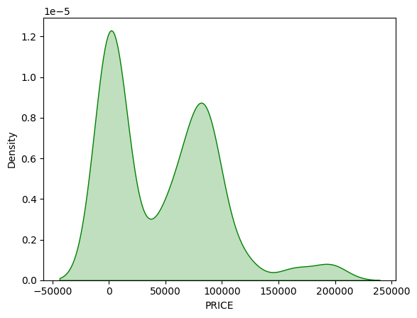

```python
sns.kdeplot(x=df['PRICE'],fill=True, color = 'green')
```

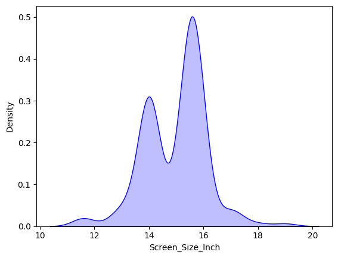

```python
sns.kdeplot(x=df['Screen_Size_Inch'],fill=True, color = 'blue')
```

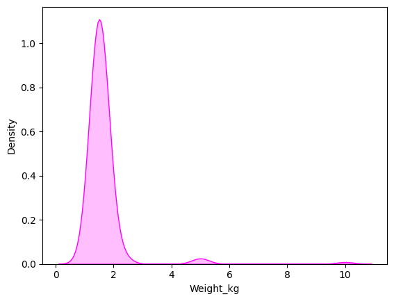

```python
sns.kdeplot(x=df['Weight_kg'],fill=True, color = 'magenta')
```

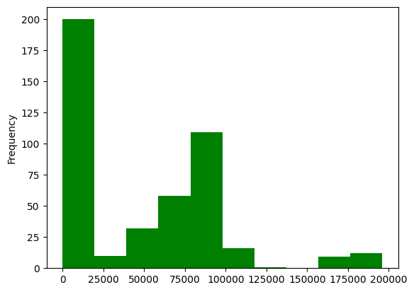

```python
df['PRICE'].plot(kind='hist', color = 'green')
```

```python
df['PRICE'].skew()  # Skewness is 0.85 means the data is moderately right-skewed, with a long tail of higher values.
```

```
np.float64(0.8569079035893804)
```

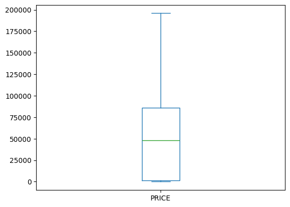

```python
df['PRICE'].plot(kind='box')
```

#### Price Analysis

```python
a = df[df['PRICE']>100000]
a
```

|  | Brand | CPU | RAM | PRICE | Rating | Screen_Size_Inch | Color | Weight_kg |
| --- | --- | --- | --- | --- | --- | --- | --- | --- |
| 2 | Ienovo | i5 | 8GB | 116990 | 4 | 14.0 | Silver | 1.51 |
| 4 | ASUS | ryzen 3 | 8GB | 164490 | 4 | 14.0 | Black | 1.38 |
| 6 | HP | ryzen 3 | 8GB | 195990 | 4 | NaN | Silver | 1.59 |
| 26 | Acer | i5 | 16GB | 116990 | 4 | NaN | Silver | 1.59 |
| 28 | HP | i7 | 8GB | 164490 | 4 | NaN | Black | 1.95 |
| 30 | ASUS | i5 | 8GB | 195990 | 4 | 14.0 | Gray | 1.50 |
| 46 | cimetech | i5 | 16GB | 124319 | 4 | NaN | Blue | NaN |
| 91 | MSI | i5 | 16GB | 116990 | 4 | 14.0 | Silver | NaN |
| 95 | ASUS | ryzen 7 | 4GB | 116990 | 3 | NaN | Silver | NaN |
| 97 | HP | i7 | 8GB | 164490 | 4 | NaN | NaN | NaN |
| 99 | HP | i3 | 12GB | 195990 | 4 | NaN | NaN | NaN |
| 115 | AS | i5 | 16GB | 112990 | 4 | NaN | NaN | NaN |
| 159 | Lenovo | i5 | 24GB | 116990 | 4 | NaN | Silver | 1.70 |
| 161 | HP | i5 | 16GB | 195990 | 4 | NaN | NaN | 1.00 |
| 164 | Lapcare | i5 | 16GB | 116990 | 4 | NaN | NaN | NaN |
| 166 | OneAssist | i5 | 16GB | 164490 | 4 | 15.0 | NaN | NaN |
| 168 | Logitech | i5 | 16GB | 195990 | 4 | NaN | Black | NaN |
| 205 | Lenovo | i5 | 24GB | 116990 | 4 | 15.3 | Silver | 1.36 |
| 207 | HP | i5 | 16GB | 195990 | 4 | NaN | NaN | NaN |
| 233 | Zebronics | i5 | 16GB | 116990 | 4 | 17.0 | NaN | NaN |
| 235 | EooCoo | i5 | 16GB | 164490 | 4 | NaN | Black | NaN |
| 237 | Klenzmo | i5 | 16GB | 195990 | 4 | NaN | Black | NaN |
| 295 | Dyazo | i5 | 16GB | 116990 | 4 | NaN | NaN | NaN |
| 297 | HP | i5 | 4GB | 195990 | 5 | 15.6 | Silver | 1.60 |
| 299 | HP | i5 | 16GB | 164490 | 4 | NaN | Silver | NaN |
| 302 | AirCase | i5 | 16GB | 116990 | 4 | 15.6 | NaN | NaN |
| 304 | Gizga | i5 | 16GB | 164490 | 4 | NaN | NaN | NaN |
| 306 | Portronics | i5 | 16GB | 195990 | 4 | NaN | Red | NaN |
| 342 | RAYA | i5 | 16GB | 116990 | 5 | 14.0 | Blue | NaN |
| 344 | HP | i5 | 4GB | 195990 | 4 | NaN | Silver | 1.38 |
| 371 | FRONTECH | i5 | 16GB | 116990 | 4 | NaN | NaN | NaN |
| 373 | Gizga | i5 | 16GB | 164490 | 4 | NaN | Black | NaN |
| 375 | eMeet | i5 | 16GB | 195990 | 4 | 15.6 | NaN | NaN |
| 436 | HP | i5 | 4GB | 116990 | 4 | NaN | Silver | 1.36 |
| 440 | Craloft | i5 | 16GB | 116990 | 5 | NaN | White | 5.00 |
| 442 | HP | i5 | 16GB | 164490 | 4 | 14.0 | Silver | 1.60 |
| 444 | Lenovo | i5 | 16GB | 195990 | 4 | 15.6 | Silver | 1.60 |

```python
len(a) # there is 37 laptops that who is having more than 1 lakh price
```

```
37
```

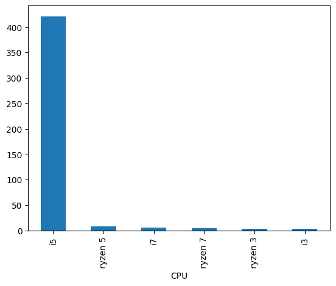

```python
df['CPU'].value_counts().plot(kind='bar')
```

```python
df.columns
```

```
Index(['Brand', 'CPU', 'RAM', 'PRICE', 'Rating', 'Screen_Size_Inch', 'Color',
       'Weight_kg'],
      dtype='object')
```

```python
df['Brand'].value_counts().head()
```

```
Brand
HP            142
Lenovo         39
Portronics     20
ASUS           17
Dyazo          10
Name: count, dtype: int64
```

```python
df['Brand'].value_counts().tail()
```

```
Brand
YFXXEEA           1
CodersParadise    1
boAt              1
Proffisy          1
MENHOOD           1
Name: count, dtype: int64
```

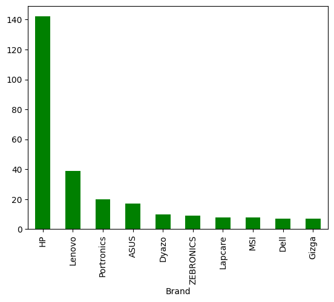

```python
df['Brand'].value_counts().head(10).plot(kind='bar',color = 'green')
```

### Bivariate Analysis

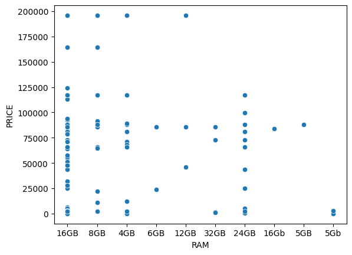

```python
sns.scatterplot(x='RAM',y='PRICE',data=df)
```

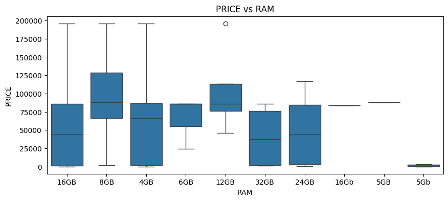

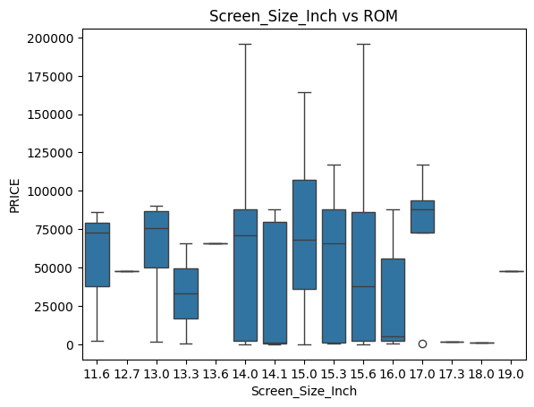

```python
plt.figure(figsize = (10,4))
sns.boxplot(x='RAM', y='PRICE', data=df)
plt.title('PRICE vs RAM')
plt.show()
sns.boxplot(x='Screen_Size_Inch', y='PRICE', data=df)
plt.title('Screen_Size_Inch vs ROM')
plt.show()
```

```python
df[df['PRICE']>=190000].value_counts() #3
```

```
Brand   CPU  RAM   PRICE   Rating  Screen_Size_Inch  Color   Weight_kg
ASUS    i5   8GB   195990  4       14.0              Gray    1.5          1
HP      i5   4GB   195990  5       15.6              Silver  1.6          1
Lenovo  i5   16GB  195990  4       15.6              Silver  1.6          1
Name: count, dtype: int64
```

```python
df[df['PRICE']>=190000].value_counts().sum()
```

```
np.int64(3)
```

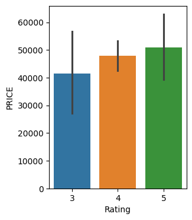

```python
plt.figure(figsize=(3,4))
sns.barplot(x=df['Rating'],y=df['PRICE'],data=df,palette='tab10')

# rating with 3 laps are getting price range between 40000 to 45000
# rating with 4 laps are getting price range approximately 45000
# rating with 5 laps are getting price range approximately 50000 or more
```

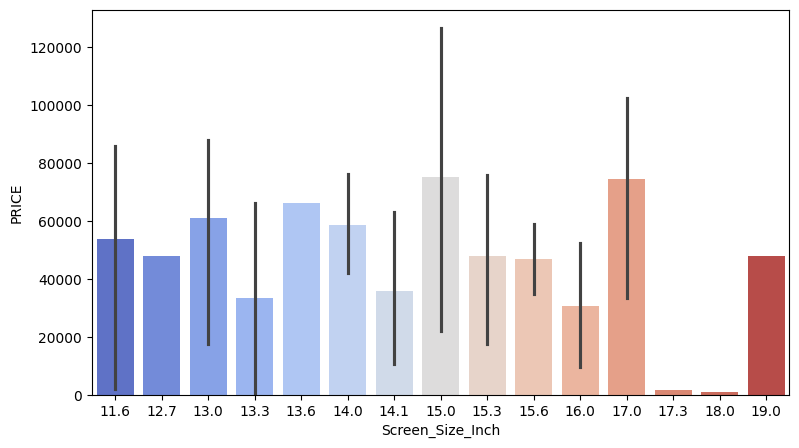

```python
plt.figure(figsize=(9,5))
sns.barplot(x=df['Screen_Size_Inch'],y=df['PRICE'],data=df,palette='coolwarm')
```

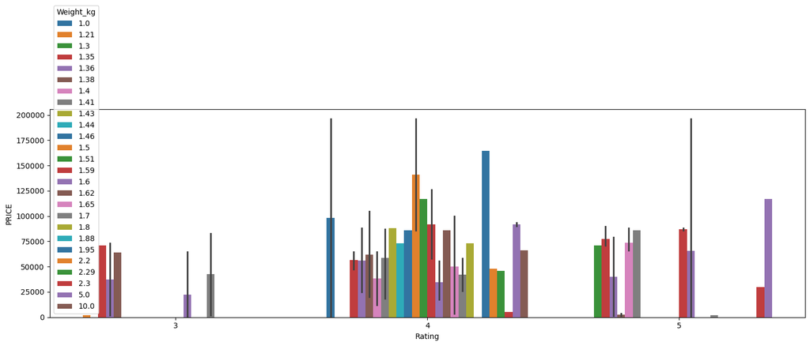

```python
plt.figure(figsize=(18,5))
sns.barplot(x=df['Rating'],y=df['PRICE'],hue='Weight_kg',data=df,palette='tab10')
```

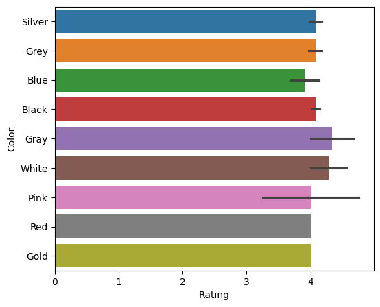

```python
plt.figure(figsize=(6,5))
sns.barplot(x=df['Rating'],y=df['Color'],data=df,palette='tab10')
```

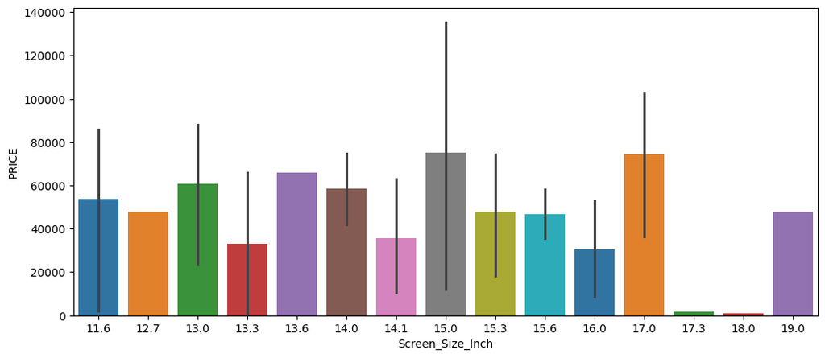

```python
plt.figure(figsize=(12,5))
sns.barplot(x=df['Screen_Size_Inch'],y=df['PRICE'],data=df,palette='tab10')
```

```python
num_cols = df.select_dtypes(include='number').columns
num_cols
```

```
Index(['PRICE', 'Rating', 'Screen_Size_Inch', 'Weight_kg'], dtype='object')
```

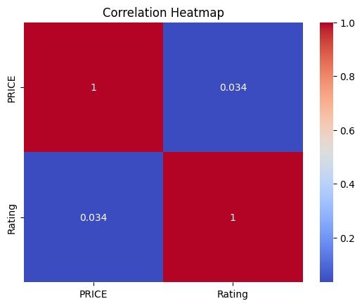

```python
sns.heatmap(
    df[['PRICE', 'Rating']].corr(),
    annot=True,
    cmap='coolwarm'
)
plt.title('Correlation Heatmap')
plt.show()
```

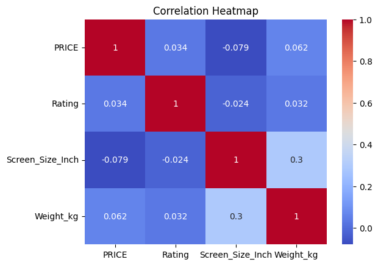

```python
sns.heatmap(df[num_cols].corr(), annot=True, cmap='coolwarm')
plt.title('Correlation Heatmap')
plt.show()
```